# Trabalho computacional ME

## importando libs

```r
library(lme4)
library(data.table)
library(zoo)
```

```r
library(ggplot2)
library(GGally)
library(zoo)
library(tseries)
library(data.table)
library(ggplot2)
library(gridExtra)
library(reshape2)
library(glmnet)
```

# AirQuality

```r
path = "C:\\Users\\mateu\\Documents\\MEGA\\Matérias UFC CD\\Modelagem Estatistica\\trabalhoPratico\\trabalho2\\dataset\\airquality.csv"
dataAir = fread(path)
```

```r
head(dataAir, n = 4)
```

| rownames | Ozone | Solar.R | Wind | Temp | Month | Day |
| --- | --- | --- | --- | --- | --- | --- |
| 1 | 41 | 190 | 7.4 | 67 | 5 | 1 |
| 2 | 36 | 118 | 8.0 | 72 | 5 | 2 |
| 3 | 12 | 149 | 12.6 | 74 | 5 | 3 |
| 4 | 18 | 313 | 11.5 | 62 | 5 | 4 |

## Analise exploratória dos dados

Quantidade de instancias

```r
length(dataAir$rownames)
```

```
## [1] 153
```

Verificando quantidade de valores únicos

```r
dataAir[, lapply( .SD, uniqueN)]
```

| rownames | Ozone | Solar.R | Wind | Temp | Month | Day |
| --- | --- | --- | --- | --- | --- | --- |
| 153 | 68 | 118 | 31 | 40 | 5 | 31 |

> Observe que $rownames$ é PK onde a quantidade de valores únicos é igual ao número de linhas do conj. de dados. Será removido do conj. de dados

```r
dataAir[,rownames:=NULL]
```

Verificando valores nulos no conj. de dados

```r
dataAir[, lapply(.SD,
                  FUN = function(x){
                      return(sum(as.numeric(is.na(x))))
                      })]
```

| Ozone | Solar.R | Wind | Temp | Month | Day |
| --- | --- | --- | --- | --- | --- |
| 37 | 7 | 0 | 0 | 0 | 0 |

> Ozone tem valores nulos

```r
dados.null = dataAir[is.na(dataAir$Ozone)==TRUE,.SD]
dados.null
```

| Ozone | Solar.R | Wind | Temp | Month | Day |
| --- | --- | --- | --- | --- | --- |
| NA | NA | 14.3 | 56 | 5 | 5 |
| NA | 194 | 8.6 | 69 | 5 | 10 |
| NA | 66 | 16.6 | 57 | 5 | 25 |
| NA | 266 | 14.9 | 58 | 5 | 26 |
| NA | NA | 8.0 | 57 | 5 | 27 |
| NA | 286 | 8.6 | 78 | 6 | 1 |
| NA | 287 | 9.7 | 74 | 6 | 2 |
| NA | 242 | 16.1 | 67 | 6 | 3 |
| NA | 186 | 9.2 | 84 | 6 | 4 |
| NA | 220 | 8.6 | 85 | 6 | 5 |

[output cut: 27 more lines]

> Como a maioria dos dados nulos são a target, vou usar as futuras features para predição dessas target

Removendo os valores nulos

```r
dataAir = na.omit(dataAir, 'Ozone')
dataAir = na.omit(dataAir, 'Solar.R')
```

```r
dataAir[, lapply(.SD,
                  FUN = function(x){
                      return(sum(as.numeric(is.na(x))))
                      })]
```

| Ozone | Solar.R | Wind | Temp | Month | Day |
| --- | --- | --- | --- | --- | --- |
| 0 | 0 | 0 | 0 | 0 | 0 |

> Os dados nulos foram removidos do conjunto de dados

```r
dataAir[, Month:=as.factor(Month)]
```

Fazendo o pairplot dos atributos para verificar o tipo de relação entre eles se é linear ou não

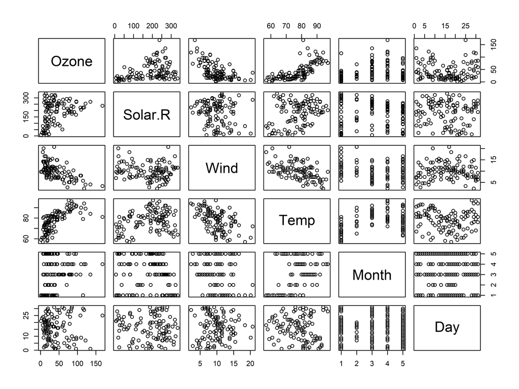

```r
pairs(dataAir)
```

```r
air = copy(dataAir)
```

Fazendo a transformação da raiz quadrada para $Ozone$

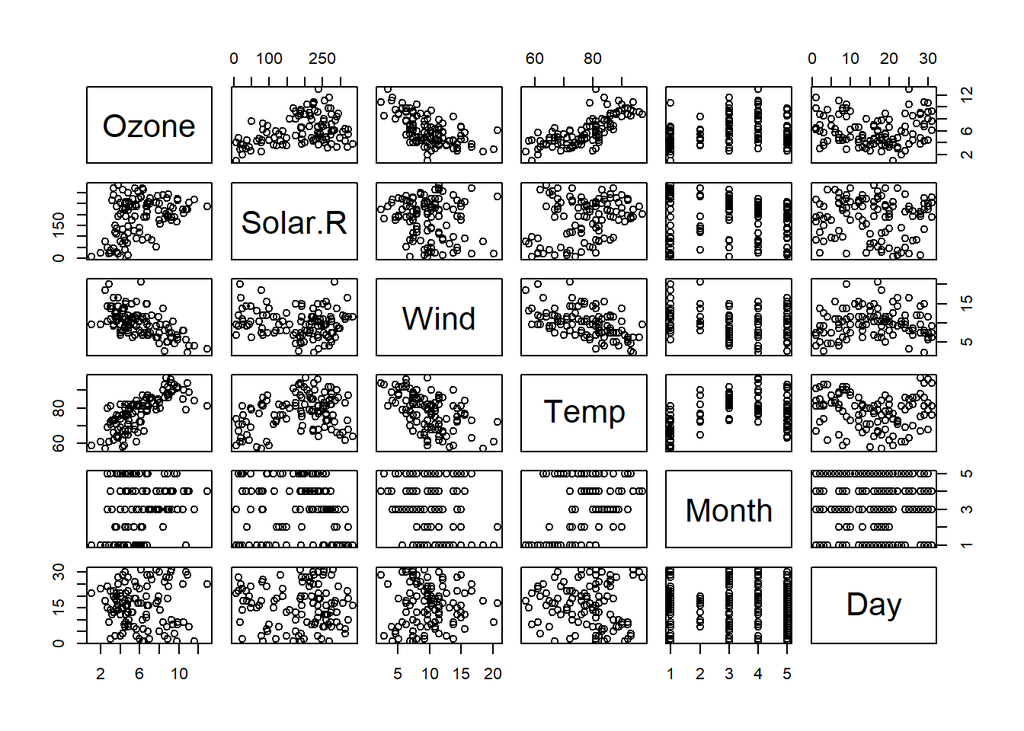

```r
air[,Ozone:=sqrt(Ozone)]
pairs(air)
```

Verificando a ozonio com base nos meses e dias

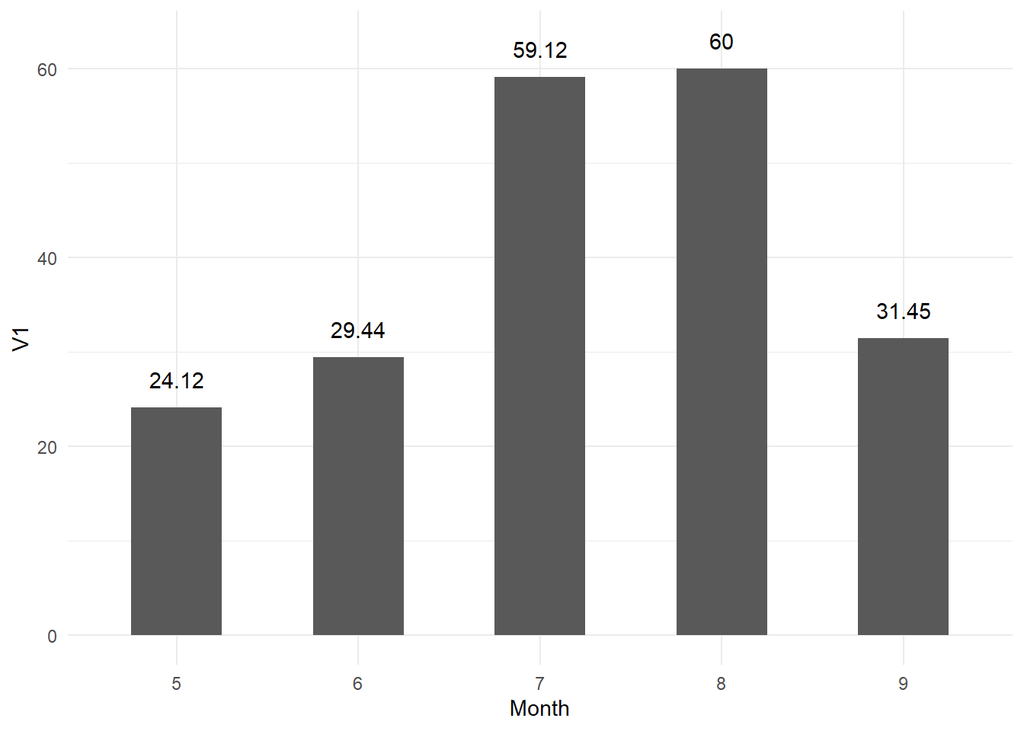

```r
subset1_ = dataAir[, mean(Ozone), by=Month]

ggplot(subset1_, aes(x=Month, y=V1)) +
  geom_bar(stat = "identity", width = 0.5) +
  geom_text(aes(label = round(V1, 2)), nudge_y = 3)+
  theme_minimal()
```

> Em média o Ozonio tem maior numeros no mes 8, 7

Verificando verificando o dia do mes com maior media de ozonio

```r
subset = dataAir
subset[, mes.dia := paste(dataAir$Month, dataAir$Day, sep='-')]
subset = subset[, mean(Ozone), by=mes.dia][order(V1, decreasing = TRUE)][1]
subset
```

| mes.dia | V1 |
| --- | --- |
| 8-25 | 168 |

> No dia 25 do mes 8 é o dia de com media de maior ozonio

Verificando a media de ozonio em relação aos dias

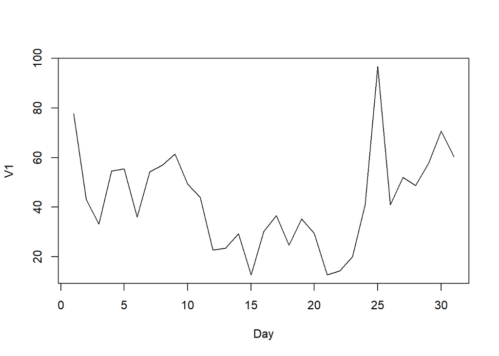

```r
subset2_ = dataAir[order(Day), mean(Ozone), by=Day]

plot(subset2_, type='l')
```

> o dia 25

Verificando a distribuição de cada atributo

```r
num_cols <- names(dataAir)[sapply(dataAir, is.numeric)]
num_cols
```

```
## [1] "Ozone"   "Solar.R" "Wind"    "Temp"    "Day"
```

```r
plots = lapply(num_cols,
               function(col) {
                 ggplot(dataAir, aes_string(x = col)) +
                   geom_histogram(aes(y = ..density..),bins = 40, fill = "#5c9ef6", color = "black") +
                   geom_density(color = "#FF0000", linewidth = 1, linetype = "dashed", adjust = 1) +
                   ggtitle(paste("Distribuição de", col))  +
                  theme_minimal()
})
# Exibindo o primeiro gráfico como exemplo
combined_plot <- do.call(grid.arrange, c(plots, ncol = 3))
```

[figure not shown]

> Vemos que os dados não seguem uma distribuição normal

Verificando a correlação dos atributos

```r
dataAir[, Month:=as.numeric(Month)]
dataAir[, mes.dia:=NULL]
```

```r
dtCor = round(cor(dataAir[,.SD], method="pearson"), 2)
dtCor = melt(dtCor)
```

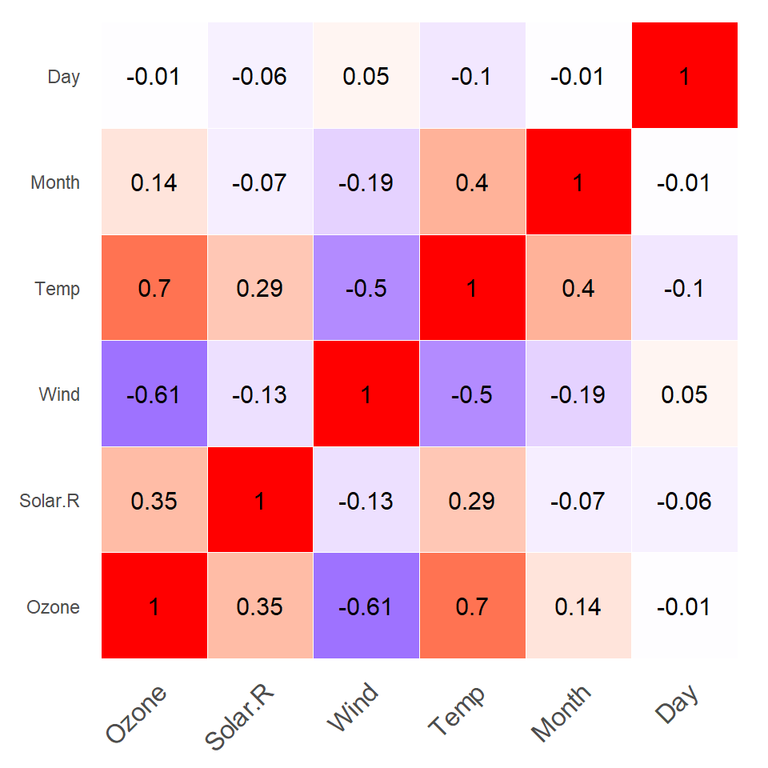

```r
ggheatmap <- ggplot(dtCor, aes(Var2, Var1, fill = value))+
 geom_tile(color = "white")+
 scale_fill_gradient2(low = "blue", high = "red", mid = "white",
   midpoint = 0, limit = c(-1,1), space = "Lab",
    name="Pearson\nCorrelation") +
  theme_minimal()+ # minimal theme
 theme(axis.text.x = element_text(angle = 45, vjust = 1,
    size = 12, hjust = 1))+
 coord_fixed()

ggheatmap +
geom_text(aes(Var2, Var1, label = value), color = "black", size = 4) +
theme(
  axis.title.x = element_blank(),
  axis.title.y = element_blank(),
  panel.grid.major = element_blank(),
  panel.border = element_blank(),
  panel.background = element_blank(),
  axis.ticks = element_blank(),
  legend.justification = c(1, 0),
  legend.position = c(1, 1),
  legend.direction = "horizontal")+
  guides(fill = guide_colorbar(barwidth = 7, barheight = 1,
                title.position = "top", title.hjust = 0.5))
```

## Criando o modelo de regressão linear

Lendo o arquivo novamente

```r
# lendo o arquivo
path = "C:\\Users\\mateu\\Documents\\MEGA\\Matérias UFC CD\\Modelagem Estatistica\\trabalhoPratico\\trabalho2\\dataset\\airquality.csv"
dataAir = fread(path)

# Removendo Rownames
dataAir[, rownames:=NULL]
dataAir[, Day:=NULL]
# removendo valores nulos
dataAir = na.omit(dataAir, 'Ozone')
dataAir = na.omit(dataAir, 'Solar.R')

# passando para as factor
#dataAir[, Month:=as.factor(Month)]


# Transformação logaritmica
dataAir[, Ozone:=log(Ozone)]
dataAir[, Wind:=log(Wind)]
dataAir[, Solar.R:=log(Solar.R)]
dataAir[, Temp:=log(Temp)]

head(dataAir, 3)
```

| Ozone | Solar.R | Wind | Temp | Month |
| --- | --- | --- | --- | --- |
| 3.713572 | 5.247024 | 2.001480 | 4.204693 | 5 |
| 3.583519 | 4.770685 | 2.079442 | 4.276666 | 5 |
| 2.484907 | 5.003946 | 2.533697 | 4.304065 | 5 |

```r
model = lm(Ozone ~. ,data = dataAir)
model
```

```
##
## Call:
## lm(formula = Ozone ~ ., data = dataAir)
##
## Coefficients:
## (Intercept)      Solar.R         Wind         Temp        Month
##   -11.34466      0.29190     -0.65866      3.47693     -0.04688
```

```r
summary(model)
```

```
##
## Call:
## lm(formula = Ozone ~ ., data = dataAir)
##
## Residuals:
##      Min       1Q   Median       3Q      Max
## -1.70869 -0.27153 -0.00702  0.31616  1.06837
##
## Coefficients:
##              Estimate Std. Error t value Pr(>|t|)
## (Intercept) -11.34466    2.16494  -5.240 8.22e-07 ***
## Solar.R       0.29190    0.05933   4.920 3.19e-06 ***
## Wind         -0.65866    0.13730  -4.797 5.29e-06 ***
## Temp          3.47693    0.50246   6.920 3.57e-10 ***
## Month        -0.04688    0.03537  -1.326    0.188
## ---
## Signif. codes:  0 '***' 0.001 '**' 0.01 '*' 0.05 '.' 0.1 ' ' 1
##
## Residual standard error: 0.4891 on 106 degrees of freedom
## Multiple R-squared:  0.6925, Adjusted R-squared:  0.6809
## F-statistic: 59.67 on 4 and 106 DF,  p-value: < 2.2e-16
```

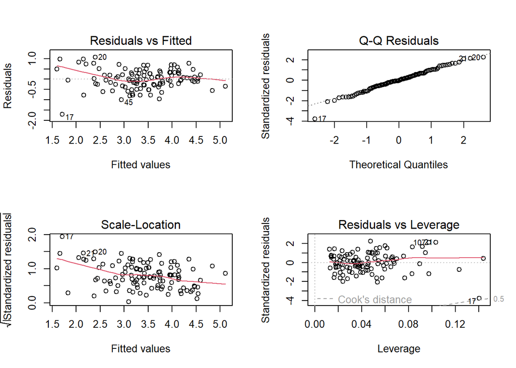

```r
par(mfrow=c(2, 2))
plot(model)
```

Como a maioria dos dados nulos são a target , então as features serão utilizadas para predição

```r
x = dados.null[, .SD, .SDcols = names(dados.null)[2:6]]
x = na.omit(x, 'Solar.R')
x = x[, Day:=NULL]
x = x[, Wind:=log(Wind)]
x = x[, Solar.R:=log(Solar.R)]
x = x[, Temp:=log(Temp)]

expm1(predict.lm(model, newdata = x, interval = 'prediction'))
```

```
##          fit       lwr       upr
## 1  25.129118  8.728642  69.17740
## 2   5.365360  1.339468  16.31924
## 3   9.906599  2.974792  28.92707
## 4  41.766205 15.047973 112.96756
## 5  31.932140 11.353129  86.79361
## 6  14.885625  4.908320  41.71148
## 7  45.684219 16.460948 123.81661
## 8  52.409019 18.966315 141.86679
## 9  30.241492 10.630072  82.92302
## 10 70.301133 25.587631 190.21115
## 11 64.513617 23.029921 177.61208
## 12 68.827521 24.787289 188.08085
## 13 34.724075 12.281338  95.09043
## 14 37.215863 13.291904 101.18738
```

[output cut: 21 more lines]

# Sleep Study

```r
path = "C:\\Users\\mateu\\Documents\\MEGA\\Matérias UFC CD\\Modelagem Estatistica\\trabalhoPratico\\trabalho2\\dataset\\sleep.csv"

sleep = fread(path)

head(sleep, 2)
```

| V1 | Reaction | Days | Subject |
| --- | --- | --- | --- |
| 1 | 249.5600 | 0 | 308 |
| 2 | 258.7047 | 1 | 308 |

Verificando únicos

```r
sleep[, lapply(.SD, uniqueN)]
```

| V1 | Reaction | Days | Subject |
| --- | --- | --- | --- |
| 180 | 180 | 10 | 18 |

V1 é o numero de intasncia do conj. dados

```r
sleep[, V1:=NULL]
```

## Analise Exploratória

```r
#sleep[, Days:=as.factor(Days)]
```

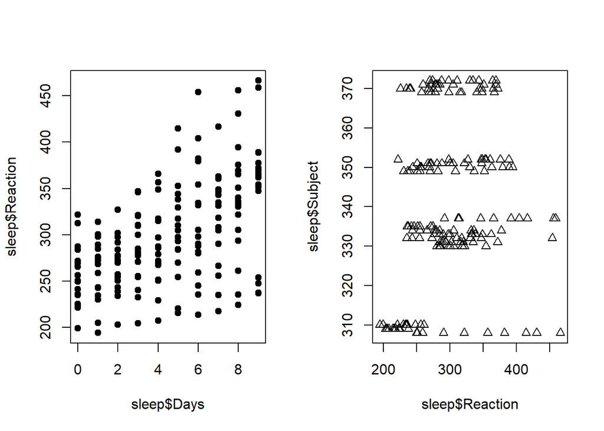

```r
par(mfrow=c(1, 2))
plot(sleep$Days, sleep$Reaction, pch=19)
plot(sleep$Reaction, sleep$Subject, pch=2)
```

## Criando modelo

```r
model.lmer = lmer(Reaction~Days + (1|Subject), data = sleep)
model.lmer
```

```
## Linear mixed model fit by REML ['lmerMod']
## Formula: Reaction ~ Days + (1 | Subject)
##    Data: sleep
## REML criterion at convergence: 1786.465
## Random effects:
##  Groups   Name        Std.Dev.
##  Subject  (Intercept) 37.12
##  Residual             30.99
## Number of obs: 180, groups:  Subject, 18
## Fixed Effects:
## (Intercept)         Days
##      251.41        10.47
```

```r
summary(model.lmer)
```

```
## Linear mixed model fit by REML ['lmerMod']
## Formula: Reaction ~ Days + (1 | Subject)
##    Data: sleep
##
## REML criterion at convergence: 1786.5
##
## Scaled residuals:
##     Min      1Q  Median      3Q     Max
## -3.2257 -0.5529  0.0109  0.5188  4.2506
##
## Random effects:
##  Groups   Name        Variance Std.Dev.
##  Subject  (Intercept) 1378.2   37.12
##  Residual              960.5   30.99
## Number of obs: 180, groups:  Subject, 18
##
## Fixed effects:
##             Estimate Std. Error t value
## (Intercept) 251.4051     9.7467   25.79
## Days         10.4673     0.8042   13.02
##
## Correlation of Fixed Effects:
##      (Intr)
## Days -0.371
```

- O efeito fixo de Days é positivo e significativo, sugerindo um crescimento ao longo do tempo.
- Existe variação entre indivíduos, pois o desvio padrão dos efeitos aleatórios é alto (37.12).
- O modelo ajusta tanto variação sistemática (efeitos fixos) quanto diferenças individuais (efeitos aleatórios).

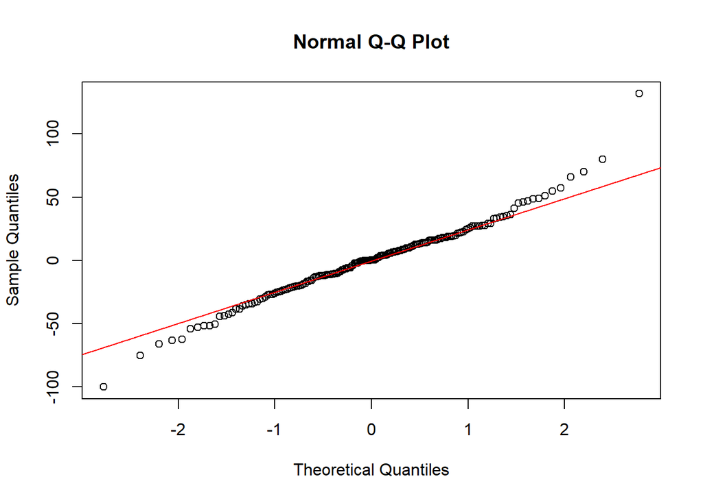

```r
# QQ plot dos resíduos
qqnorm(resid(model.lmer))
qqline(resid(model.lmer), col = "red")
```

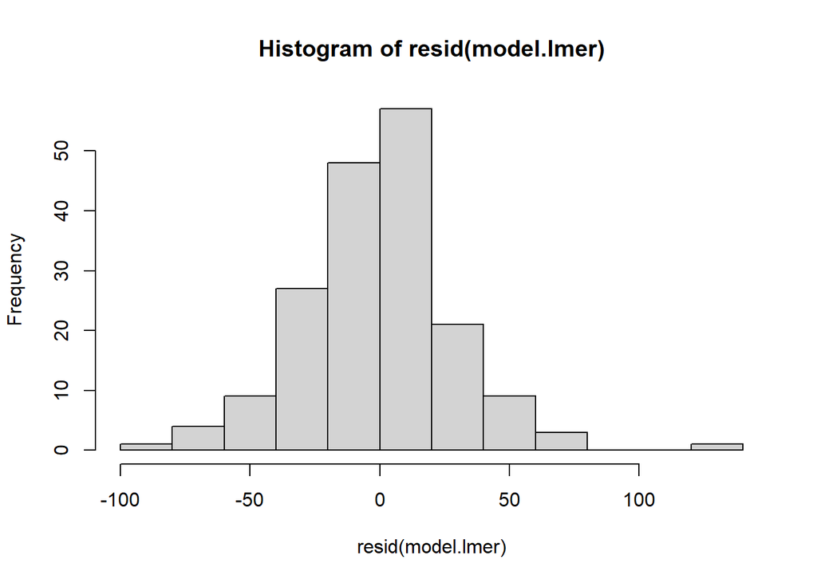

```r
hist(resid(model.lmer), 10)
```

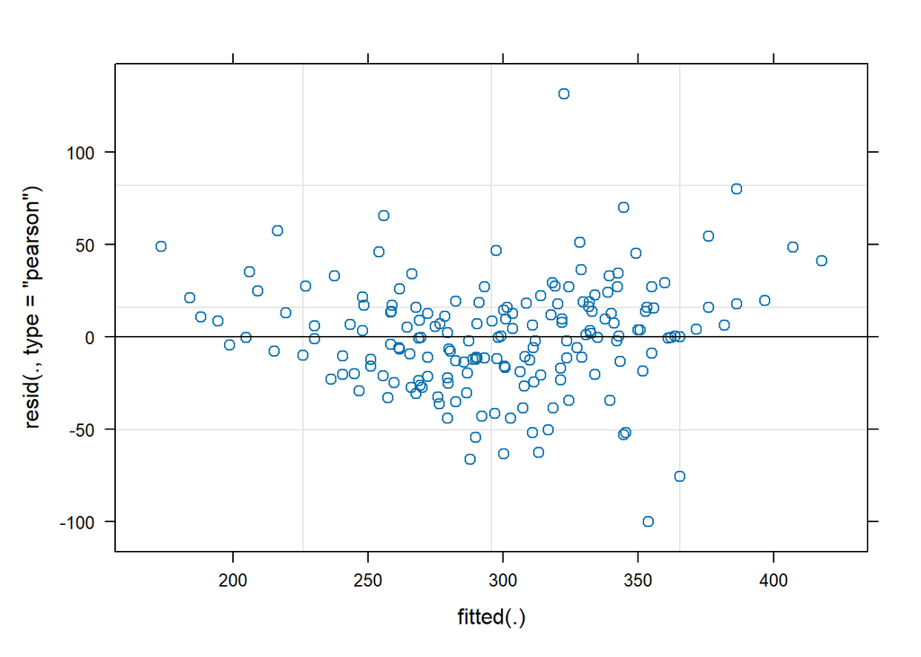

```r
plot(model.lmer)
```

# Metanalise

```r
path = "C:\\Users\\mateu\\Documents\\MEGA\\Matérias UFC CD\\Modelagem Estatistica\\trabalhoPratico\\trabalho2\\dataset\\metanalise.csv"
meta = fread(path)

head(meta, n = 3)
```

| V1 | yi | vi | cluster | randomized |
| --- | --- | --- | --- | --- |
| 1 | -0.388300800 | 0.113865100 | ACE 2013a | FALSE |
| 2 | 0.001426734 | 0.008177298 | ACE 2013a | FALSE |
| 3 | -0.077824834 | 0.015627721 | ACE 2013b | FALSE |

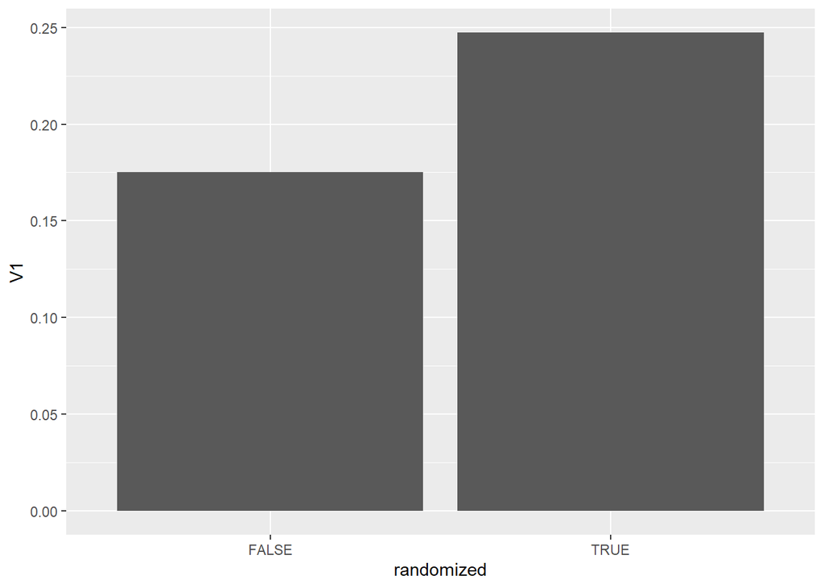

```r
subset = meta[, mean(yi), by=randomized]


ggplot(subset, aes(x = randomized, y=V1)) +
  geom_bar(stat = "identity")
```

```r
# Pegando o nome do autor
meta[, cluster_name:=unlist(lapply(meta$cluster, function(x){
                                              return(c(strsplit(x, ' ',fixed = TRUE))[[1]][1])
                                          }))
]
```

```r
# Pegando o ano

lista_num = unlist(lapply(
  meta$cluster, function(x){
    x = c(strsplit(x, ' ', fixed = TRUE))
    for(i in x[[1]]){

      string = i
      string = sub('a', '', string)
      string = sub('b', '', string)
      if (!anyNA(suppressWarnings(as.numeric(string)))){
        return(as.numeric(string))
    }
  }})
)

meta[, cluster_year := lista_num]
```

Removendo a coluna cluste e V1

```r
meta[, cluster:=NULL]
meta[, V1:=NULL]
```

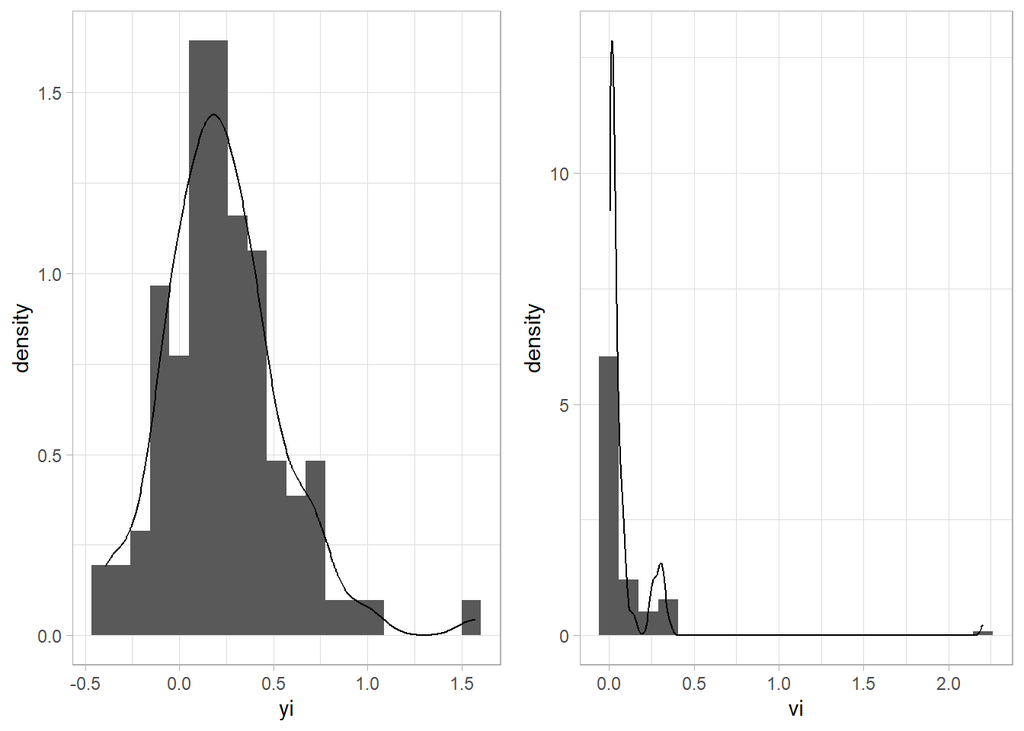

```r
plots = lapply(c("yi", "vi"),
              function(x){
                ggplot(data = meta, mapping = aes_string(x = x)) +
                  geom_histogram(aes(y = ..density..) , bins = 20) +
                  geom_density() +
                  theme_light()
              })

combined_plot <- do.call(grid.arrange, c(plots, ncol = 2))
```

```r
shapiro.test(meta$vi)
```

```
##
##  Shapiro-Wilk normality test
##
## data:  meta$vi
## W = 0.32394, p-value < 2.2e-16
```

```r
shapiro.test(meta$yi)
```

```
##
##  Shapiro-Wilk normality test
##
## data:  meta$yi
## W = 0.95498, p-value = 0.001792
```

Verificando a presença de outliers nos atributos log da razão de chances e erro padrão

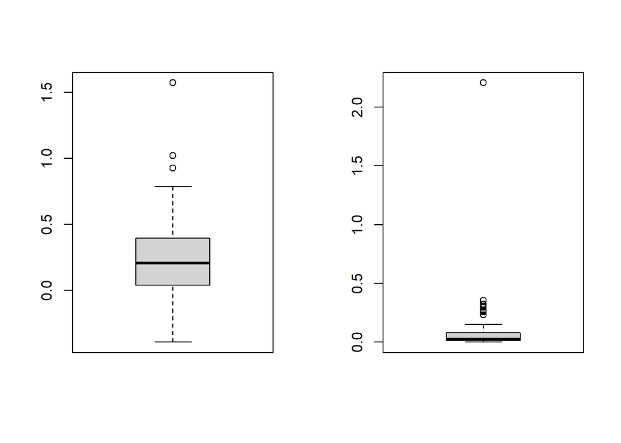

```r
par(mfrow=c(1,2))
boxplot(meta$yi)
boxplot(meta$vi)
```

> Vemos a presença de outliers em ambos atributos

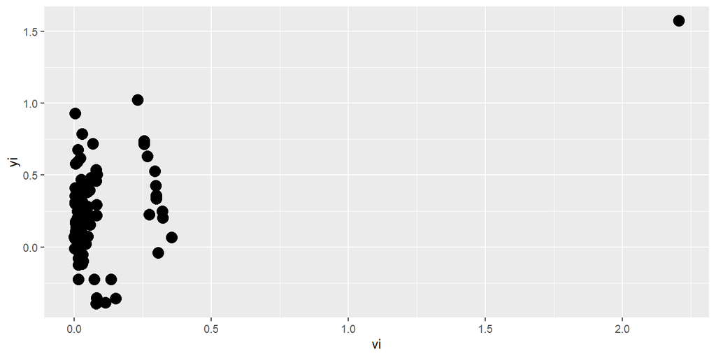

```r
ggplot(data = meta, mapping = aes(x = vi, y =yi)) +
  geom_point(size=4) +
  theme(legend.position = "none")
```

> Vemos que o outliers bem distante da concentração dos dados

```r
cor(meta$vi, meta$yi)
```

```
## [1] 0.46873
```

Para não remover o outliers vamos ver se a transformação log ou sqrt atenua esse ploblema, além a inversa da log

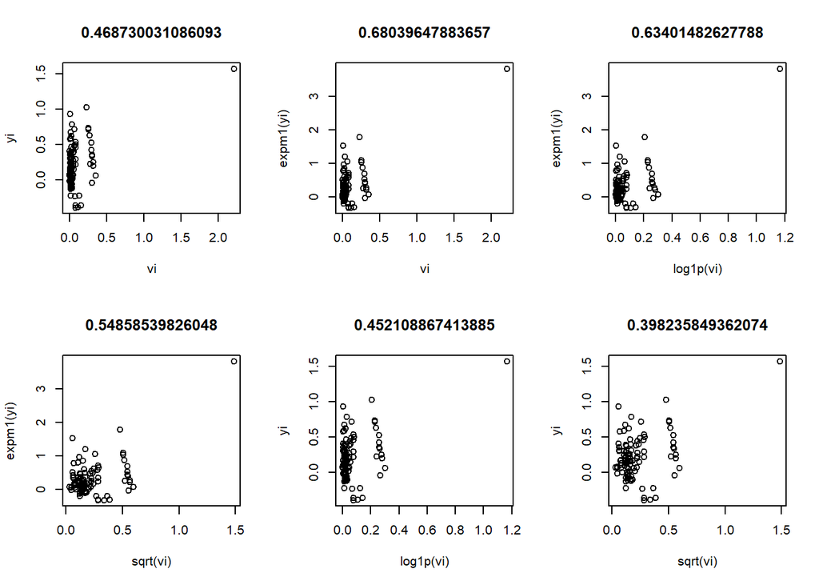

```r
par(mfrow=c(2, 3))

yi = meta$yi
vi = meta$vi
plot(vi, yi)
title(cor(vi, yi))

plot(vi, expm1(yi))
title(cor(vi, expm1(yi)))

plot(log1p(vi), expm1(yi))
title(cor(log1p(vi), expm1(yi)))

plot(sqrt(vi), expm1(yi))
title(cor(sqrt(vi), expm1(yi)))

plot(log1p(vi), yi)
title(cor(log1p(vi), yi))

plot(sqrt(vi), yi)
title(cor(sqrt(vi), yi))
```

Passando randomized para int

```r
meta[, randomized:=as.integer(randomized)]
```

```r
meta.sem.outlier = meta
```

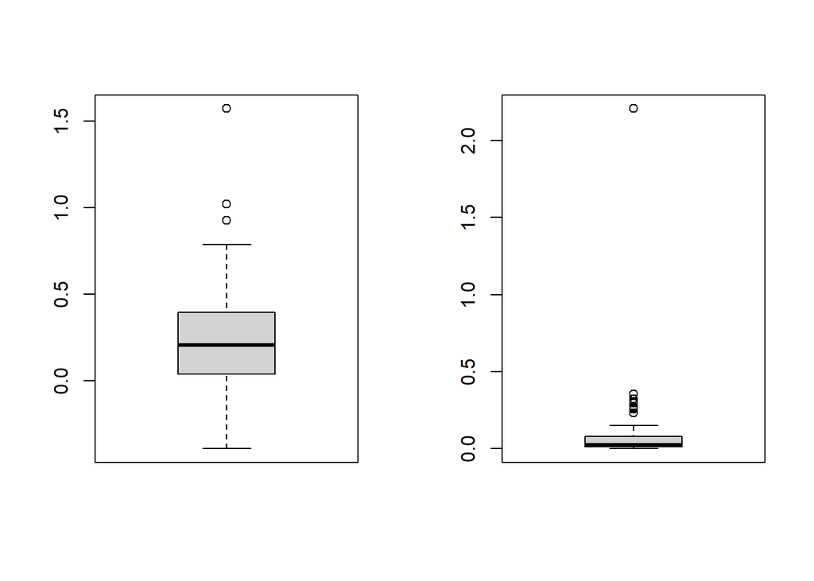

```r
par(mfrow=c(1, 2))
boxplot(meta.sem.outlier$yi)
boxplot(meta.sem.outlier$vi)
```

> Remover os outliers tendo como base $yi$

```r
remove_outliers_iqr <- function(data, column) {
  Q1 <- quantile(data[[column]], 0.25, na.rm = TRUE)
  Q3 <- quantile(data[[column]], 0.75, na.rm = TRUE)
  IQR <- Q3 - Q1

  lower_bound <- Q1 - 1.5 * IQR
  upper_bound <- Q3 + 1.5 * IQR

  data_clean <- data[data[[column]] >= lower_bound & data[[column]] <= upper_bound, ]
  return(data_clean)
}


meta.sem.outlier = remove_outliers_iqr(meta.sem.outlier, 'yi')
```

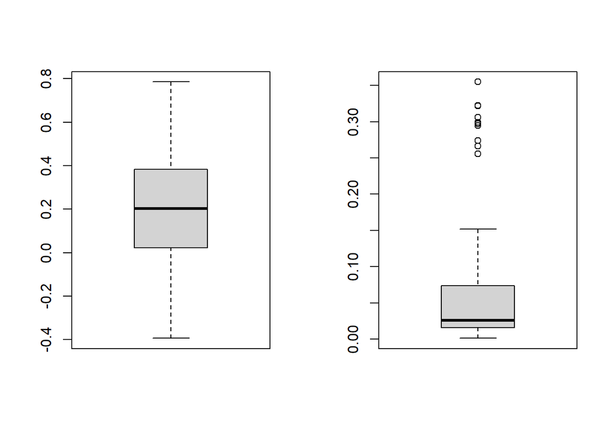

```r
par(mfrow=c(1, 2))
boxplot(meta.sem.outlier$yi)
boxplot(meta.sem.outlier$vi)
```

## Criando Modelo

```r
# Criar modelo inicial
model.meta <- lm(expm1(yi) ~ ., data = meta)

# Stepwise selection usando AIC
model.step <- step(model.meta, direction = "both", trace = TRUE)
```

```
## Start:  AIC=-202.14
## expm1(yi) ~ vi + randomized + cluster_name + cluster_year
##
##                Df Sum of Sq     RSS     AIC
## - cluster_year  1    0.0175  7.2873 -203.90
## <none>                       7.2698 -202.15
## - randomized    1    0.2007  7.4704 -201.42
## - cluster_name 26    6.7490 14.0187 -188.48
## - vi            1    5.3741 12.6439 -148.80
##
## Step:  AIC=-203.9
## expm1(yi) ~ vi + randomized + cluster_name
##
##                Df Sum of Sq     RSS     AIC
## <none>                       7.2873 -203.90
## - randomized    1    0.1831  7.4704 -203.42
## + cluster_year  1    0.0175  7.2698 -202.15
## - cluster_name 26    7.2985 14.5858 -186.51
## - vi            1    5.3859 12.6731 -150.57
```

```r
# Ver resultado final do modelo reduzido
summary(model.step)
```

```
##
## Call:
## lm(formula = expm1(yi) ~ vi + randomized + cluster_name, data = meta)
##
## Residuals:
##      Min       1Q   Median       3Q      Max
## -0.58729 -0.13885  0.00000  0.08348  1.32726
##
## Coefficients:
##                             Estimate Std. Error t value Pr(>|t|)
## (Intercept)                 -0.19001    0.18514  -1.026 0.308233
## vi                           1.26967    0.17527   7.244 4.18e-10 ***
## randomized                  -0.27687    0.20728  -1.336 0.185904
## cluster_nameAmiot            0.87946    0.42405   2.074 0.041711 *
## cluster_nameAnderson         0.58861    0.33384   1.763 0.082179 .
## cluster_nameBertolaso        0.71713    0.32073   2.236 0.028502 *
## cluster_nameByrd-Bredbenner  0.87257    0.42405   2.058 0.043289 *
## cluster_nameCaldwell         0.90937    0.31258   2.909 0.004835 **
## cluster_nameCooney           0.17675    0.21487   0.823 0.413484
## cluster_nameCordts           1.62219    0.42406   3.825 0.000278 ***
## cluster_nameDoebel           0.83448    0.32073   2.602 0.011279 *
## cluster_nameEarle            1.33856    0.35852   3.734 0.000378 ***
## cluster_nameFeltz            0.05518    0.36994   0.149 0.881852
## cluster_nameFIAPO            1.20657    0.28830   4.185 8.05e-05 ***
## cluster_nameFlens            0.11109    0.36996   0.300 0.764850
## cluster_nameHennessy         0.28790    0.35851   0.803 0.424635
## cluster_nameKunst            0.79425    0.30710   2.586 0.011753 *
## cluster_nameLackner          0.06488    0.42409   0.153 0.878837
## cluster_nameMacDonald        0.53544    0.35855   1.493 0.139778
## cluster_nameNorris           0.49961    0.22309   2.239 0.028260 *
## cluster_nameNovotna          0.78478    0.35847   2.189 0.031867 *
## cluster_namePalomo-Velez     0.64258    0.33379   1.925 0.058220 .
## cluster_nameReese            0.62654    0.29097   2.153 0.034696 *
## cluster_nameRouk             0.87810    0.30707   2.860 0.005566 **
## cluster_nameSchnabelrauch    0.64787    0.30706   2.110 0.038390 *
## cluster_nameSchwitzgebel     0.32659    0.37000   0.883 0.380389
## cluster_nameSilva            0.63961    0.35849   1.784 0.078664 .
## cluster_nameSpanikova        0.03529    0.35885   0.098 0.921932
## cluster_nameTian             0.53436    0.32071   1.666 0.100079
## ---
## Signif. codes:  0 '***' 0.001 '**' 0.01 '*' 0.05 '.' 0.1 ' ' 1
##
## Residual standard error: 0.3204 on 71 degrees of freedom
## Multiple R-squared:  0.7324, Adjusted R-squared:  0.6269
## F-statistic: 6.941 on 28 and 71 DF,  p-value: 2.131e-11
```

```r
summary(model.meta)
```

```
##
## Call:
## lm(formula = expm1(yi) ~ ., data = meta)
##
## Residuals:
##      Min       1Q   Median       3Q      Max
## -0.58751 -0.13942  0.00000  0.08258  1.32722
##
## Coefficients:
##                              Estimate Std. Error t value Pr(>|t|)
## (Intercept)                  46.10729  112.68120   0.409 0.683654
## vi                            1.26846    0.17633   7.194 5.54e-10 ***
## randomized                   -0.30307    0.21804  -1.390 0.168936
## cluster_nameAmiot             1.02067    0.54779   1.863 0.066621 .
## cluster_nameAnderson          0.69909    0.43021   1.625 0.108656
## cluster_nameBertolaso         0.78929    0.36734   2.149 0.035121 *
## cluster_nameByrd-Bredbenner   0.82978    0.43908   1.890 0.062924 .
## cluster_nameCaldwell          1.01836    0.41138   2.475 0.015730 *
## cluster_nameCooney            0.20774    0.22892   0.907 0.367260
## cluster_nameCordts            1.67138    0.44304   3.773 0.000335 ***
## cluster_nameDoebel            0.90673    0.36743   2.468 0.016044 *
## cluster_nameEarle             1.50272    0.53823   2.792 0.006749 **
## cluster_nameFeltz             0.19316    0.50125   0.385 0.701144
## cluster_nameFIAPO             1.29940    0.36763   3.535 0.000729 ***
## cluster_nameFlens             0.22605    0.46560   0.486 0.628834
## cluster_nameHennessy          0.38306    0.42860   0.894 0.374520
## cluster_nameKunst             0.90475    0.40959   2.209 0.030454 *
## cluster_nameLackner           0.22913    0.58462   0.392 0.696304
## cluster_nameMacDonald         0.63059    0.42862   1.471 0.145712
## cluster_nameNorris            0.58086    0.29911   1.942 0.056170 .
## cluster_nameNovotna           0.94900    0.53830   1.763 0.082273 .
## cluster_namePalomo-Velez      0.78375    0.48040   1.631 0.107287
## cluster_nameReese             0.69901    0.34173   2.046 0.044564 *
## cluster_nameRouk              0.99628    0.42207   2.360 0.021045 *
## cluster_nameSchnabelrauch     0.74307    0.38613   1.924 0.058366 .
## cluster_nameSchwitzgebel      0.46453    0.50124   0.927 0.357232
## cluster_nameSilva             0.73479    0.42860   1.714 0.090880 .
## cluster_nameSpanikova         0.10761    0.40160   0.268 0.789515
## cluster_nameTian              0.62954    0.39716   1.585 0.117446
## cluster_year                 -0.02300    0.05598  -0.411 0.682423
## ---
## Signif. codes:  0 '***' 0.001 '**' 0.01 '*' 0.05 '.' 0.1 ' ' 1
##
## Residual standard error: 0.3223 on 70 degrees of freedom
## Multiple R-squared:  0.7331, Adjusted R-squared:  0.6225
## F-statistic: 6.629 on 29 and 70 DF,  p-value: 5.325e-11
```

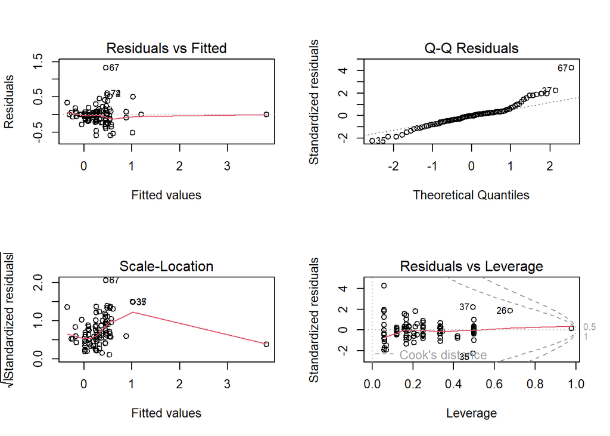

```r
par(mfrow=c(2, 2))
plot(model.meta)
```

## Criando modelo sem outliers

```r
model.meta.sem.outlier = lm(yi ~. , data = meta.sem.outlier)

model.meta.sem.outlier
```

```
##
## Call:
## lm(formula = yi ~ ., data = meta.sem.outlier)
##
## Coefficients:
##                 (Intercept)                           vi
##                   15.558718                     1.560326
##                  randomized            cluster_nameAmiot
##                   -0.246188                     0.818552
##        cluster_nameAnderson        cluster_nameBertolaso
##                    0.613433                     0.700317
## cluster_nameByrd-Bredbenner         cluster_nameCaldwell
##                    0.757623                     0.817319
##          cluster_nameCooney           cluster_nameCordts
##                    0.211427                     1.219737
##          cluster_nameDoebel            cluster_nameEarle
##                    0.739634                     1.134314
##           cluster_nameFeltz            cluster_nameFIAPO
##                    0.124467                     0.662594
##           cluster_nameFlens         cluster_nameHennessy
##                    0.179503                     0.297296
##           cluster_nameKunst          cluster_nameLackner
##                    0.767768                     0.038062
##       cluster_nameMacDonald           cluster_nameNorris
##                    0.561590                     0.500644
##         cluster_nameNovotna     cluster_namePalomo-Velez
##                    0.744951                     0.662469
##           cluster_nameReese             cluster_nameRouk
##                    0.368800                     0.811731
##   cluster_nameSchnabelrauch     cluster_nameSchwitzgebel
##                    0.628096                     0.398374
##           cluster_nameSilva        cluster_nameSpanikova
##                    0.642874                    -0.024692
##            cluster_nameTian                 cluster_year
##                    0.543172                    -0.007842
```

```r
summary(model.meta.sem.outlier)
```

```
##
## Call:
## lm(formula = yi ~ ., data = meta.sem.outlier)
##
## Residuals:
##      Min       1Q   Median       3Q      Max
## -0.39969 -0.09538  0.00000  0.07201  0.45846
##
## Coefficients:
##                              Estimate Std. Error t value Pr(>|t|)
## (Intercept)                 15.558718  69.715454   0.223  0.82408
## vi                           1.560326   0.606038   2.575  0.01225 *
## randomized                  -0.246188   0.134353  -1.832  0.07134 .
## cluster_nameAmiot            0.818552   0.338378   2.419  0.01828 *
## cluster_nameAnderson         0.613433   0.265276   2.312  0.02383 *
## cluster_nameBertolaso        0.700317   0.226508   3.092  0.00290 **
## cluster_nameByrd-Bredbenner  0.757623   0.270591   2.800  0.00667 **
## cluster_nameCaldwell         0.817319   0.253602   3.223  0.00196 **
## cluster_nameCooney           0.211427   0.141499   1.494  0.13982
## cluster_nameCordts           1.219737   0.272994   4.468 3.12e-05 ***
## cluster_nameDoebel           0.739634   0.228269   3.240  0.00186 **
## cluster_nameEarle            1.134314   0.331607   3.421  0.00107 **
## cluster_nameFeltz            0.124467   0.309034   0.403  0.68841
## cluster_nameFIAPO            0.662594   0.267871   2.474  0.01592 *
## cluster_nameFlens            0.179503   0.286857   0.626  0.53360
## cluster_nameHennessy         0.297296   0.264142   1.126  0.26439
## cluster_nameKunst            0.767768   0.252356   3.042  0.00335 **
## cluster_nameLackner          0.038062   0.362682   0.105  0.91673
## cluster_nameMacDonald        0.561590   0.264455   2.124  0.03740 *
## cluster_nameNorris           0.500644   0.184630   2.712  0.00850 **
## cluster_nameNovotna          0.744951   0.332949   2.237  0.02859 *
## cluster_namePalomo-Velez     0.662469   0.295989   2.238  0.02854 *
## cluster_nameReese            0.368800   0.253533   1.455  0.15044
## cluster_nameRouk             0.811731   0.260088   3.121  0.00266 **
## cluster_nameSchnabelrauch    0.628096   0.238278   2.636  0.01042 *
## cluster_nameSchwitzgebel     0.398374   0.308843   1.290  0.20152
## cluster_nameSilva            0.642874   0.264060   2.435  0.01758 *
## cluster_nameSpanikova       -0.024692   0.256190  -0.096  0.92351
## cluster_nameTian             0.543172   0.244688   2.220  0.02982 *
## cluster_year                -0.007842   0.034631  -0.226  0.82155
## ---
## Signif. codes:  0 '***' 0.001 '**' 0.01 '*' 0.05 '.' 0.1 ' ' 1
##
## Residual standard error: 0.1985 on 67 degrees of freedom
## Multiple R-squared:  0.6052, Adjusted R-squared:  0.4342
## F-statistic: 3.541 on 29 and 67 DF,  p-value: 1.012e-05
```

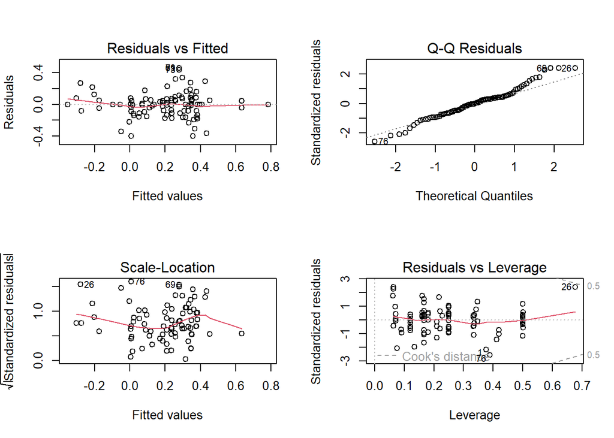

```r
par(mfrow=c(2, 2))
plot(model.meta.sem.outlier)
```